# Lab 2

## Density plot.

### Compare the default bandwidth with a few other selections entered manually. Settle on a bandwidth selection, and justify why briefly in text.

Time for density plots! We can get a better sense of the overall shape of the distribution this way. We’ll take a first stab at the plot with the default bandwidth.

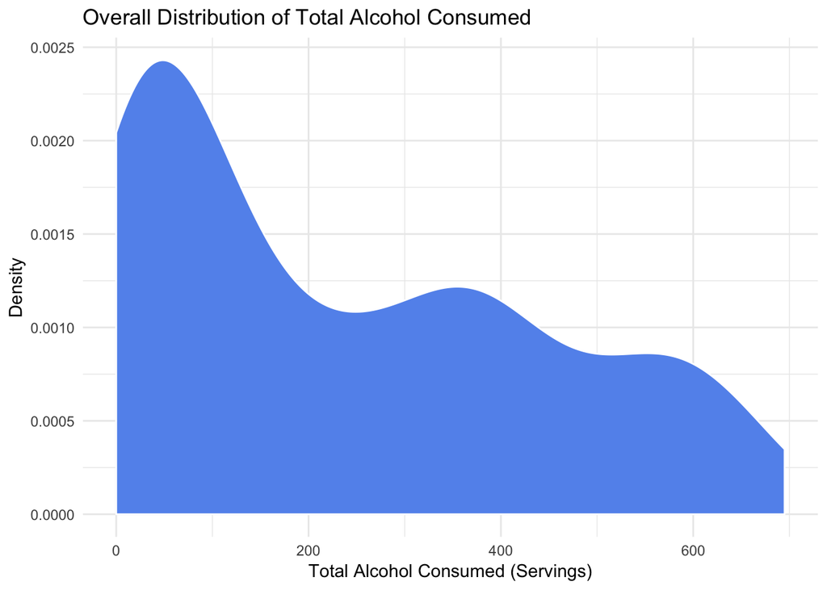

```r
ggplot(d, aes(total)) +
  geom_density(color = "white", fill = "cornflowerblue") +
  theme_minimal() +
  labs(x = "Total Alcohol Consumed (Servings)", y = "Density") +
  ggtitle("Overall Distribution of Total Alcohol Consumed")
```

Now, let’s get down the business of bandwidth! The default bandwidth admittedly provides a pretty nice depiction of the distribution. We want the bandwidth to help approximate the underlying continuous probability function, while still keeping true to the original data.

To be sure, though, let’s try decreasing the bandwidth a bit, to conform even more to the original data. We’ll set bandwidth to 10.

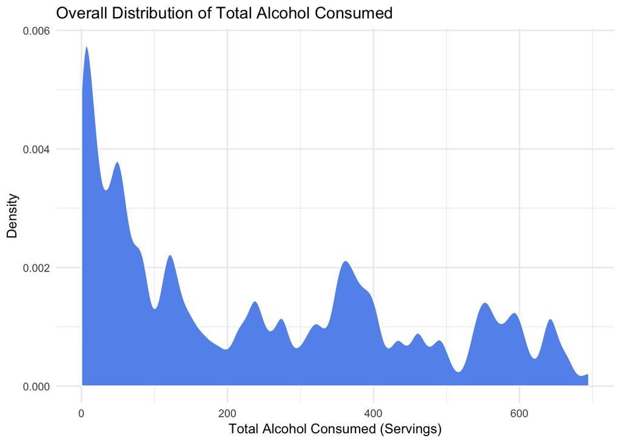

```r
ggplot(d, aes(total)) +
  geom_density(color = "white", fill = "cornflowerblue", bw = 10) +
  theme_minimal() +
  labs(x = "Total Alcohol Consumed (Servings)", y = "Density") +
  ggtitle("Overall Distribution of Total Alcohol Consumed")
```

Yikes. A little too jagged there. Perhaps a bigger bandwidth might work better.

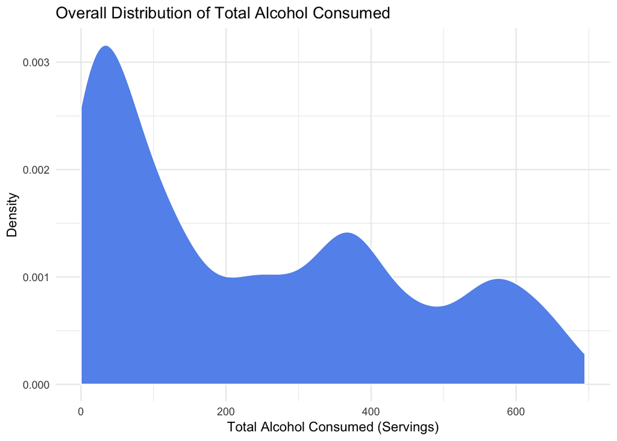

```r
library(ggplot2)

ggplot(d, aes(total)) +
  geom_density(color = "white", fill = "cornflowerblue", bw = 40) +
  theme_minimal() +
  labs(x = "Total Alcohol Consumed (Servings)", y = "Density") +
  ggtitle("Overall Distribution of Total Alcohol Consumed")
```

A bandwidth of 40 looks about right. A tighter fit to the original data than the default density plot, but still a smooth trimodal distribution overall.

# 3. Reorganize the data so you have a type and servings column.

Let’s get polish up those old tidyverse skills.

```r
library(tidyverse)

d_tidy <- d %>%
  gather("type", "servings", -country, -total, -liters) %>%
  mutate(type = as.factor(type))

levels(d_tidy$type) <- c("Beer", "Spirits", "Wine")
```

# 4. Evaluate the distribution of servings by type using at least three different methods. Provide a brief substantive conclusion.

Now that we’ve successfully reorganized the data, let’s take a look at the distribution of servings by type with a few different visualizations. We’ll start with a bar graph

## Bar Graph

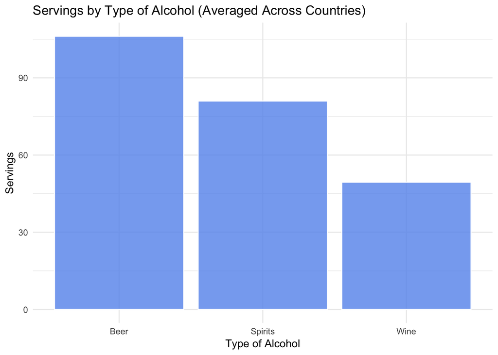

```r
ggplot(d_tidy, aes(type, servings)) +
  geom_bar(fill = "cornflowerblue", color = "white", stat = "summary", alpha = 0.8) +
  theme_minimal() +
  labs(x = "Type of Alcohol", y = "Servings") +
  ggtitle("Servings by Type of Alcohol (Averaged Across Countries)")
```

## Bar Graph + Jitter Plot

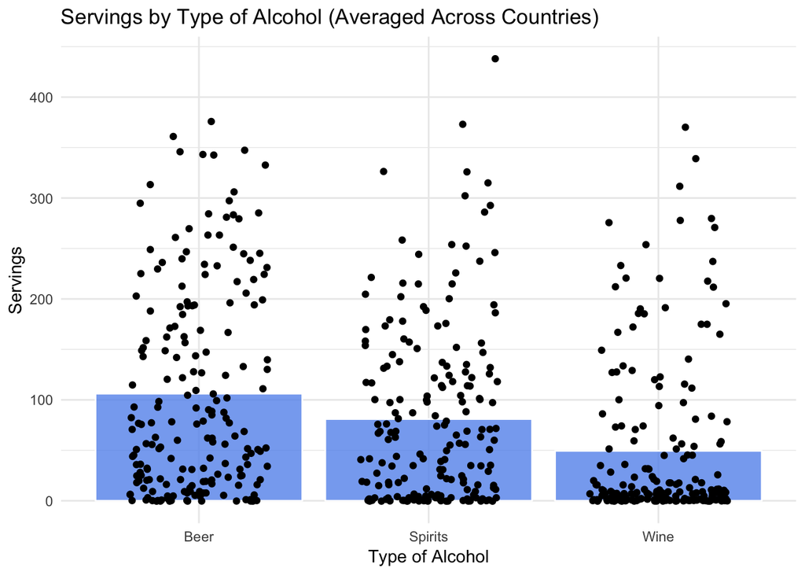

```r
ggplot(d_tidy, aes(type, servings)) +
  geom_bar(fill = "cornflowerblue", color = "white", stat = "summary", alpha = 0.8) +
  geom_jitter(stat = "identity", width = 0.3) +
  theme_minimal() +
  labs(x = "Type of Alcohol", y = "Servings") +
  ggtitle("Servings by Type of Alcohol (Averaged Across Countries)")
```

This is much more informative. Now, within each of the three alcoholic beverage types, we get a sense of their underlying distributions. There is a similar range in servings of each alcohol type consumed, but spirits and wine are more positively skewed than beer is.

But, hey, speaking of distributions, we can make our visualization a bit more explicit in that respect, huh? In fact, why use blocky bars to provide summary information when we can use violin plots instead?

## Violin Plot + Jitter Plot

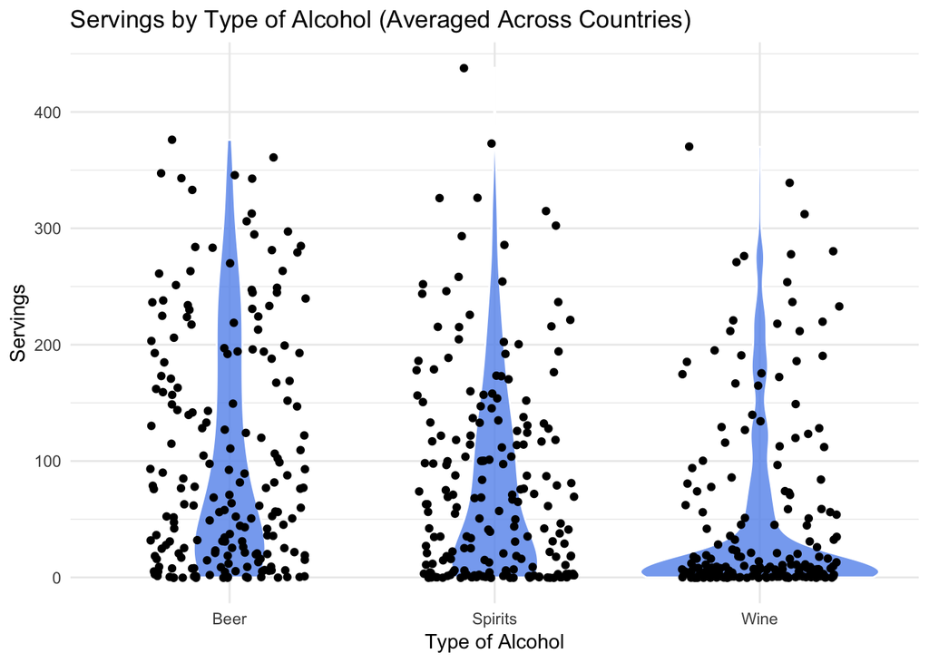

```r
ggplot(d_tidy, aes(type, servings)) +
  geom_violin(fill = "cornflowerblue", color = "white", alpha = 0.8) +
  geom_jitter(stat = "identity", width = 0.3) +
  theme_minimal() +
  labs(x = "Type of Alcohol", y = "Servings") +
  ggtitle("Servings by Type of Alcohol (Averaged Across Countries)")
```

Here, we get a sense of just how positively skewed the distribution for wine is. Nearly all countries are clumped at < 50 servings. I’m not so much of a wine guy myself. Bring on the beer servings, please and thanks!

# 5. Reproduce the plot.

Can do! First, we’ll have to subset the original dataset to the top 25 countries by alcohol consumption. We can do this with the `top_n` command. We’ll simply tell R to return the top 25 countries in the “total” servings of alcohol variable we computed earlier. A nifty trick in just a single line of code!

Then, we’ll tidy up the new dataframe as we did before by creating an individual column for both alcohol type and number of servings.

```r
top <- top_n(d, 25, total)

top <- top %>%
  gather("type", "servings", -country, -total, -liters) %>%
  mutate(type = as.factor(type))

levels(top$type) <- c("Beer", "Spirits", "Wine")
```

Finally, we’ll reproduce that plot. Nothing a little `coord_flip` can’t solve. There is one notable difference in my plot as compared to the sample, however. I reordered my countries in terms of their overall alcohol consumption by serving. For example, with 695 servings, Andorra is the #1 biggest alcohol consumer in the world, followed by Grenada with 665 servings.

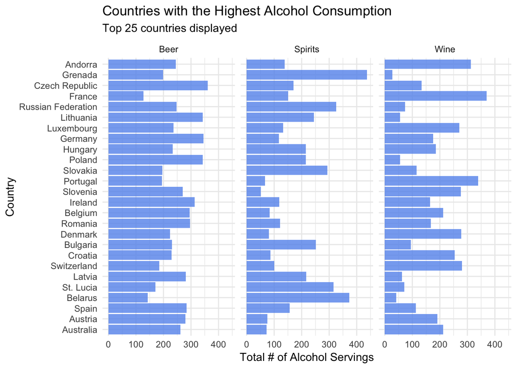

```r
ggplot(top, aes(reorder(country, servings), servings)) +
  geom_bar(stat = "identity", fill = "cornflowerblue", alpha = 0.8) +
  coord_flip() +
  facet_wrap(~type) +
  theme_minimal() +
  labs(x = "Country", y = "Total # of Alcohol Servings") +
  ggtitle("Countries with the Highest Alcohol Consumption", subtitle = "Top 25 countries displayed")
```

Also, wow: Counter to stereotypes, Ireland didn’t even crack the top 10.